This notebook is presented for the website https://zhengwangada.github.io/

### Group member: Zheng Wang, Joy Zhuge

# Data Analysis Based on Video game sales data

In this tutorial, We will investigate the video game sales data, tidy it and provide some valuable insights. This data comes from Kaggle.com and contains more than 16000 games. With all these information, we may observe something interesting.

## Data Collection

In the first stage, we choose 3 datasets to start the project. Both datasets are downloaded from www.Kaggle.com. They are relatively clear to analysize and visualize. Since we both interested in video game, we choose our primary *Video Game Sales* data and *Google Play Store Apps* as the backup plan.

We use *Video Game Sales* as primary dataset since it is our common interest. This dataset contains detailed sales data in different place. The second dataset we interested in is *Google Play Store Apps*. This dataset provides information of 9660 unique apps on Android platform. Some of them are very polular and high-rated. A complimentary dataset would be Apple iOS app store statistics, we can also compare the performance of the same app on different platforms.

The third dataset is GDP data which contains GDP in different areas from 1960 to 2018. It is very possible that game sales is related to the overall economy.

### dataset 1: Video game sales

we get this dataset from https://www.kaggle.com/gregorut/videogamesales

The video game sales dataset contains 16,598 games with sales greater than 100,000 copies, generated by a scrape of vgchartz.com . It has 11 attributes including:

#### Columns of video game sales:

- Rank-ranking of overall sales
- Name-the video game name
- Platform-platform of the games release(i.e. Wii, Nes, GB, PC, PS4, etc. 31 values)
- Year-year of the game’s release
- Genre-genre of the game(i.e. action, sports, etc. 12 values)
- Publisher-publisher of the game(i.e. electronic arts, Activision, Nintendo, etc. 579 values)
- NA_sales-total sales in North America(in million)
- EU_sales-total sales in Europe(in million)
- JP_sales-total sales in Japan(in million)
- Other_sales-total sales in the rest of the world(in million)
- Global_sales-total worldwide sales

#### Problems and interest points:

- Is the ranking associates with genre or the platform?
- What is the trend of genre of popular video games over years? Does it have relationship with the platform? How does it distributed?
- What is the most popular platform for video games over the years? We can analyze it with the platform publication news.
- Does different publisher has a trend to publish a specific genre of video games?
- Compare the sales over different areas, compute the ratio between sales and population, does it have relationship with the development of the area?
- Does different areas has different favor of genre or platform of the video game? We can analyze it considering the culture and publisher of areas.

We can visualize the above questions with kinds of vivid plots, and tidy the data focusing on each individual question.

### dataset 2: Google Play Store Apps

we download this data from https://www.kaggle.com/lava18/google-play-store-apps

The Play Store apps data has enormous potential to drive app-making businesses to success. Some insights can be drawn for developers to work on and capture the Android market.

There are 13 columns and 9660 rows in this dataset. Each row contains a unique App from Google Play Store

#### Attributes of google play store apps:

- App: name of the App
- Category: type of the App
- Rating: application's rating on playstore
- Reviews: number of reviews
- Size: size of app in M, sometimes varies with device.
- Installs: number of instrallments
- Type: whether the app is *free* or *paid*
- Price: price of the App in dollar, if the app is free, price equals to zero
- Content Rating: everyone, teens, mature 17+ etc. 7 values total
- Genres: App genres(i.e. tools, education, lifestyle etc. 120 values total)
- Last Updated: data of latest update
- Current Ver: latest App version
- Android Ver: Minimum Android Version required to run the App

#### Problems:

- Why some apps are high-rated while other not?
- Is rating related to genres?
- Is high rating apps always updating?
- If we are developing a new app on Android, how to get our app high_rated?
- Given other information, can we predict the rating of an app?

## Data Processing: Extraction, Transform, Load and Data Analysis

We use video games sales data to finish this part. One complementary data is GDP per capita from 1960 to 2018, which helps us to calculate the correlation coefficient with the sales. The video games dataset is already pretty tidy. But we can see there are around 300 null data in *Year* and 50 null data in *Publisher*. We believe it is neither caused by scraping or original web don't have this information (missing at random).

Consider it too exhausted to google each game and fill in the blank we don't have a good way to fill in and none of these data has high rank and the missing number is not that large, we will just use drop null to ignore them.

```python
import sqlite3
import pandas as pd
import numpy as np
import seaborn as sns
from matplotlib import cm
import matplotlib.pyplot as plt
from scipy import stats
import statistics
```

```python
# read dataset
vgsales_df = pd.read_csv('./vgsales.csv')
vgsales_df.head()
```

|  | Rank | Name | Platform | Year | Genre | Publisher | NA_Sales | EU_Sales | JP_Sales | Other_Sales | Global_Sales |
| --- | --- | --- | --- | --- | --- | --- | --- | --- | --- | --- | --- |
| 0 | 1 | Wii Sports | Wii | 2006.0 | Sports | Nintendo | 41.49 | 29.02 | 3.77 | 8.46 | 82.74 |
| 1 | 2 | Super Mario Bros. | NES | 1985.0 | Platform | Nintendo | 29.08 | 3.58 | 6.81 | 0.77 | 40.24 |
| 2 | 3 | Mario Kart Wii | Wii | 2008.0 | Racing | Nintendo | 15.85 | 12.88 | 3.79 | 3.31 | 35.82 |
| 3 | 4 | Wii Sports Resort | Wii | 2009.0 | Sports | Nintendo | 15.75 | 11.01 | 3.28 | 2.96 | 33.00 |
| 4 | 5 | Pokemon Red/Pokemon Blue | GB | 1996.0 | Role-Playing | Nintendo | 11.27 | 8.89 | 10.22 | 1.00 | 31.37 |

```python
# get a summary for all data
vgsales_df.info()
```

```
<class 'pandas.core.frame.DataFrame'>
RangeIndex: 16598 entries, 0 to 16597
Data columns (total 11 columns):
Rank            16598 non-null int64
Name            16598 non-null object
Platform        16598 non-null object
Year            16327 non-null float64
Genre           16598 non-null object
Publisher       16540 non-null object
NA_Sales        16598 non-null float64
EU_Sales        16598 non-null float64
JP_Sales        16598 non-null float64
Other_Sales     16598 non-null float64
Global_Sales    16598 non-null float64
dtypes: float64(6), int64(1), object(4)
memory usage: 1.4+ MB
```

Let's take a look at the missing data and determine how to deal with it.

```python
vgsales_df[vgsales_df['Year'].isnull()==True].head()
```

|  | Rank | Name | Platform | Year | Genre | Publisher | NA_Sales | EU_Sales | JP_Sales | Other_Sales | Global_Sales |
| --- | --- | --- | --- | --- | --- | --- | --- | --- | --- | --- | --- |
| 179 | 180 | Madden NFL 2004 | PS2 | NaN | Sports | Electronic Arts | 4.26 | 0.26 | 0.01 | 0.71 | 5.23 |
| 377 | 378 | FIFA Soccer 2004 | PS2 | NaN | Sports | Electronic Arts | 0.59 | 2.36 | 0.04 | 0.51 | 3.49 |
| 431 | 432 | LEGO Batman: The Videogame | Wii | NaN | Action | Warner Bros. Interactive Entertainment | 1.86 | 1.02 | 0.00 | 0.29 | 3.17 |
| 470 | 471 | wwe Smackdown vs. Raw 2006 | PS2 | NaN | Fighting | NaN | 1.57 | 1.02 | 0.00 | 0.41 | 3.00 |
| 607 | 608 | Space Invaders | 2600 | NaN | Shooter | Atari | 2.36 | 0.14 | 0.00 | 0.03 | 2.53 |

```python
vgsales_df[vgsales_df['Publisher'].isnull()==True].head()
```

|  | Rank | Name | Platform | Year | Genre | Publisher | NA_Sales | EU_Sales | JP_Sales | Other_Sales | Global_Sales |
| --- | --- | --- | --- | --- | --- | --- | --- | --- | --- | --- | --- |
| 470 | 471 | wwe Smackdown vs. Raw 2006 | PS2 | NaN | Fighting | NaN | 1.57 | 1.02 | 0.0 | 0.41 | 3.00 |
| 1303 | 1305 | Triple Play 99 | PS | NaN | Sports | NaN | 0.81 | 0.55 | 0.0 | 0.10 | 1.46 |
| 1662 | 1664 | Shrek / Shrek 2 2-in-1 Gameboy Advance Video | GBA | 2007.0 | Misc | NaN | 0.87 | 0.32 | 0.0 | 0.02 | 1.21 |
| 2222 | 2224 | Bentley's Hackpack | GBA | 2005.0 | Misc | NaN | 0.67 | 0.25 | 0.0 | 0.02 | 0.93 |
| 3159 | 3161 | Nicktoons Collection: Game Boy Advance Video V... | GBA | 2004.0 | Misc | NaN | 0.46 | 0.17 | 0.0 | 0.01 | 0.64 |

So far, nothing shows structural error, so we can just drop the missing data.

## Exploratory Analysis & Data Visualization

### Ranking over Genre/Platform

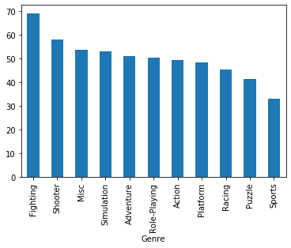

```python
# top 500 rank with genre
vgtop500=vgsales_df[vgsales_df["Rank"]<=100]
vgtop500.groupby("Genre")["Rank"].mean().sort_values(ascending = False).plot.bar()
```

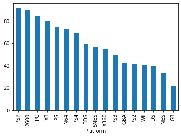

```python
# top 500 rank with platform
vgtop500=vgsales_df[vgsales_df["Rank"]<=100]
vgtop500.groupby("Platform")["Rank"].mean().sort_values(ascending = False).plot.bar()
```

## Trends of Genre or Platform over Years

In this part, we want to know the trend of genre/platform of popular video games over years. We calculate how many video games published in the each year of each genre and platform. Since there are so many platforms, and lots of them are not well-known, we only plot the top 10 platforms which has the most video games.

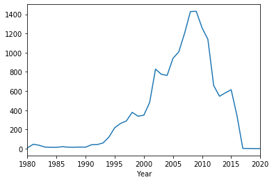

```python
# overall video game counts by year
vgsales_df.groupby("Year")["Name"].count().plot.line()
```

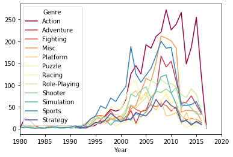

```python
# trend of genre over years
cmap = cm.get_cmap('Spectral')
vgsales_df.pivot_table(index="Year",columns=["Genre"],values="Name",aggfunc=np.size).plot.line(legend=True,cmap=cmap)
```

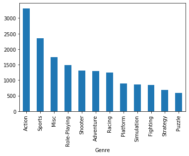

```python
# overall video game counts by genre
vgsales_df.groupby("Genre")["Name"].count().sort_values(ascending = False).plot.bar()
```

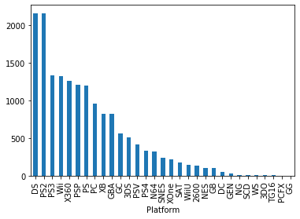

```python
# overall video game counts by platform
vgsales_df.groupby("Platform")["Name"].count().sort_values(ascending = False).plot.bar()
```

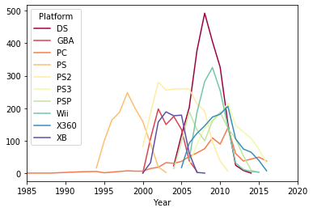

```python
# trends of top10 platform over years
vgsales_df = pd.read_csv('./vgsales.csv')
temp_platform=vgsales_df.groupby("Platform")["Name"].count().nlargest(10).to_frame()
top10_platform=temp_platform.merge(vgsales_df,on=["Platform"],how="inner")
top10_platform.pivot_table(index="Year",columns=["Platform"],values="Name_y",aggfunc=np.size).plot.line(legend=True,cmap=cmap)
```

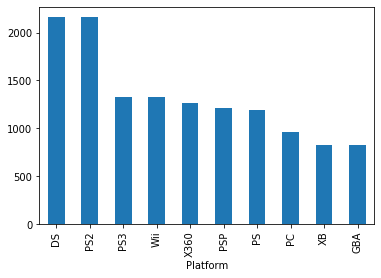

```python
# overall video game counts by top10 platform
top10_platform.groupby("Platform")["Name_y"].count().sort_values(ascending = False).plot.bar()
```

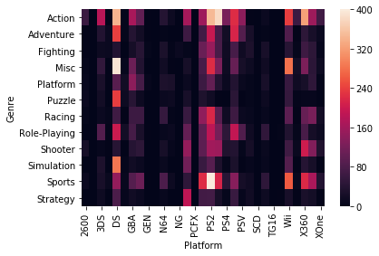

```python
# genre vs. platform
genre_platform = pd.crosstab(vgsales_df['Genre'],vgsales_df['Platform'])
sns.heatmap(genre_platform)
```

## Sales (Percentage) of Each Area in Each Genre

In this part, we are interested in each genre of video games sales in every area. We drawed heatmap among genre and area in absolute sale numbers and percentage sales(each genre has 100 percent), and the percentage heatmap is more clear than the actual amount, NA take a large amount in every genre, but JP has a flavor in Role-Playing specifically, which is quite fitting in the Japanese Cosplay culture. To be more clear, we also drawed stacked bar plot of the percentage plot.

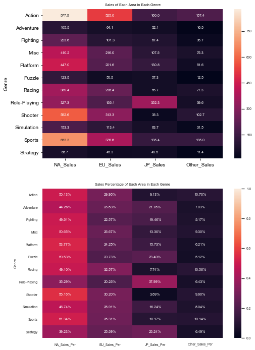

```python
genre=vgsales_df.groupby("Genre").sum()
genre["NA_Sales_Per"]=genre["NA_Sales"]/genre["Global_Sales"]
genre["EU_Sales_Per"]=genre["EU_Sales"]/genre["Global_Sales"]
genre["JP_Sales_Per"]=genre["JP_Sales"]/genre["Global_Sales"]
genre["Other_Sales_Per"]=genre["Other_Sales"]/genre["Global_Sales"]
plt.figure(figsize=(8,12))
plt.subplot(211)
sns.set(font_scale=0.6)
sales=genre.loc[:,'NA_Sales':'Other_Sales']
ax1=sns.heatmap(sales, annot=True, fmt = '.1f')
bottom,top=ax1.get_ylim()
ax1.set_ylim(bottom,top)
plt.title("Sales of Each Area in Each Genre")
plt.subplot(212)
percen=genre.loc[:,'NA_Sales_Per':'Other_Sales_Per']
ax2=sns.heatmap(percen, vmax =1, vmin=0, annot=True, fmt = '.2%')
bottom,top=ax2.get_ylim()
ax2.set_ylim(bottom,top)
plt.title("Sales Percentage of Each Area in Each Genre")
plt.show()
```

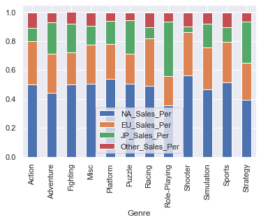

```python
sns.set()
percen.plot.bar(stacked=True)
```

## Trends of Area Sales (Percentage) over Years

In this part, we ploted the sales percentage of four areas over years to see the trends. It fits the conclusion we got from above sections.

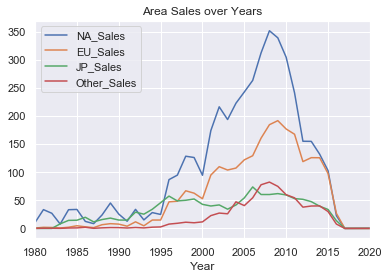

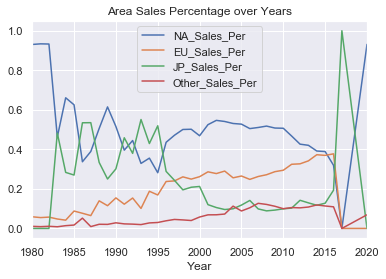

```python
years=vgsales_df.groupby("Year").sum()
years["NA_Sales_Per"]=years["NA_Sales"]/years["Global_Sales"]
years["EU_Sales_Per"]=years["EU_Sales"]/years["Global_Sales"]
years["JP_Sales_Per"]=years["JP_Sales"]/years["Global_Sales"]
years["Other_Sales_Per"]=years["Other_Sales"]/years["Global_Sales"]
plt.figure(figsize=(8,12))
sales_year=years.loc[:,'NA_Sales':'Other_Sales']
sales_year.plot.line(legend=True,title="Area Sales over Years")

percen_year=years.loc[:,'NA_Sales_Per':'Other_Sales_Per']
percen_year.plot.line(legend=True,title="Area Sales Percentage over Years")
```

## Correlation of GDP of Areas

In this part, we found a dataset of GDP in NA, EU, JP and world. We grouped the video games dataset by years, and sum the sales for each year, we computed the correlation coefficient of sales and GDP for each area across year and made a bar plot to visualize it.

- All the correlation coefficients are positive and over 0.6, which makes sense to say the sales is positive correlative with GDP.
- Europe has the highest corrlation coefficient which is over 0.8, we consider it highly correlated.

```python
gdp_df = pd.read_csv('./GDP_pc.csv',sep ='\t')
gdp_df.info()
```

```
<class 'pandas.core.frame.DataFrame'>
RangeIndex: 59 entries, 0 to 58
Data columns (total 5 columns):
Year             59 non-null int64
Euro area        59 non-null float64
North America    59 non-null float64
Japan            59 non-null float64
World            59 non-null float64
dtypes: float64(4), int64(1)
memory usage: 2.4 KB
```

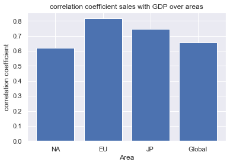

```python
# make year of vgsales as int64 to match GDP
vgsales_df['Year'] = vgsales_df['Year'].fillna(0).astype(np.int64)
years=vgsales_df.groupby("Year").sum()
cross=years.merge(gdp_df,on=['Year'],how="inner")
corr_NA=cross["NA_Sales"].corr(cross["North America"])
corr_EU=cross["EU_Sales"].corr(cross["Euro area"])
corr_JP=cross["JP_Sales"].corr(cross["Japan"])
corr_global=cross["Global_Sales"].corr(cross["World"])
x=['NA','EU','JP','Global']
y=[corr_NA,corr_EU,corr_JP,corr_global]
x_pos=[i for i, _ in enumerate(x)]
plt.bar(x_pos,y)
plt.xlabel("Area")
plt.ylabel("correlation coefficient")
plt.title("correlation coefficient sales with GDP over areas")
plt.xticks(x_pos,x)
plt.show()
```

## Does different publisher has a trend to publish a specific genre of video games?

Does different publisher has a trend to publish a specific genre of video games? Our first guess is yes. Based on history and techonology background, different company has different preference. Once a company launched a successful game, it is highly possible for them produce a follow_up and than developed as a preference. Let's first take a look at the publishers of top 100 video games. These games are produced by 11 different publisher. From the last column our first table, we can see Nintendo owns 52 of 100 top games. This is so surprising!

| Genre Publisher | Action | Adventure | Fighting | Misc | Platform | Puzzle | Racing | Role-Playing | Shooter | Simulation | Sports | sum |
| --- | --- | --- | --- | --- | --- | --- | --- | --- | --- | --- | --- | --- |
| Nintendo | 2 | 1 | 2 | 5 | 15 | 2 | 5 | 11 | 2 | 3 | 4 | 52 |
| Activision | 0 | 0 | 0 | 0 | 0 | 0 | 0 | 0 | 14 | 0 | 0 | 14 |
| Take-Two Interactive | 9 | 0 | 0 | 0 | 0 | 0 | 0 | 0 | 0 | 0 | 0 | 9 |
| Sony Computer Entertainment | 0 | 0 | 0 | 0 | 1 | 0 | 5 | 2 | 0 | 0 | 0 | 8 |
| Microsoft Game Studios | 0 | 0 | 0 | 2 | 0 | 0 | 0 | 0 | 4 | 0 | 0 | 6 |
| Electronic Arts | 1 | 0 | 0 | 0 | 0 | 0 | 0 | 0 | 2 | 1 | 1 | 5 |
| Ubisoft | 0 | 0 | 0 | 2 | 0 | 0 | 0 | 0 | 0 | 0 | 0 | 2 |
| Atari | 0 | 0 | 0 | 0 | 0 | 1 | 0 | 0 | 0 | 0 | 0 | 1 |
| Bethesda Softworks | 0 | 0 | 0 | 0 | 0 | 0 | 0 | 1 | 0 | 0 | 0 | 1 |
| Sega | 0 | 0 | 0 | 0 | 0 | 0 | 0 | 0 | 0 | 0 | 1 | 1 |
| SquareSoft | 0 | 0 | 0 | 0 | 0 | 0 | 0 | 1 | 0 | 0 | 0 | 1 |

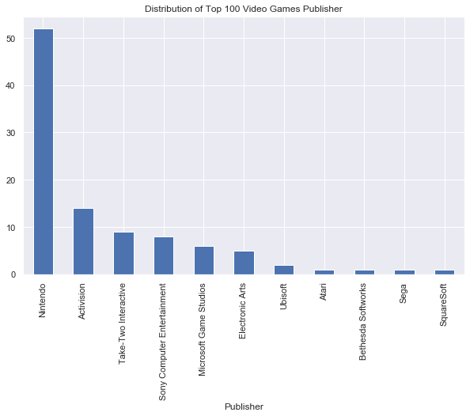

```python
rank_100 = vgsales_df[vgsales_df['Rank']<= 100]
rank_100_publisher = pd.crosstab(rank_100['Publisher'], rank_100['Genre'])
rank_100_publisher['sum'] = np.sum(rank_100_publisher, axis = 1)
rank_100_publisher = rank_100_publisher.sort_values(by = 'sum', ascending = False)
display(rank_100_publisher)
pub_sum = rank_100_publisher['sum']
fig = plt.figure(figsize=(10,6))
pub_sum.plot.bar()
plt.title('Distribution of Top 100 Video Games Publisher')
```

```python
# list the publisher we are interested
great_pub = ['Nintendo', 'Activision', 'Take-Two Interactive',
       'Sony Computer Entertainment', 'Microsoft Game Studios',
       'Electronic Arts', 'Ubisoft', 'Sega']
# Does different publisher has a trend to publish a specific genre of video games?
genre_pub = pd.crosstab(vgsales_df['Publisher'], vgsales_df['Genre'])
pub_genre = genre_pub[genre_pub.index.isin(great_pub)]
pub_genre = np.transpose(pub_genre)
pub_genre
```

| Publisher Genre | Activision | Electronic Arts | Microsoft Game Studios | Nintendo | Sega | Sony Computer Entertainment | Take-Two Interactive | Ubisoft |
| --- | --- | --- | --- | --- | --- | --- | --- | --- |
| Action | 310 | 183 | 21 | 79 | 101 | 90 | 93 | 193 |
| Adventure | 25 | 13 | 3 | 35 | 31 | 41 | 12 | 59 |
| Fighting | 7 | 39 | 5 | 18 | 37 | 30 | 1 | 19 |
| Misc | 103 | 46 | 34 | 100 | 62 | 128 | 27 | 151 |
| Platform | 60 | 16 | 6 | 112 | 52 | 66 | 11 | 70 |
| Puzzle | 7 | 7 | 1 | 74 | 22 | 12 | 1 | 24 |
| Racing | 74 | 159 | 22 | 37 | 48 | 65 | 20 | 52 |
| Role-Playing | 41 | 35 | 16 | 106 | 64 | 49 | 6 | 41 |
| Shooter | 159 | 139 | 28 | 26 | 40 | 51 | 65 | 92 |
| Simulation | 23 | 116 | 18 | 29 | 12 | 15 | 4 | 119 |
| Sports | 144 | 561 | 17 | 55 | 135 | 124 | 151 | 72 |
| Strategy | 22 | 37 | 18 | 32 | 35 | 12 | 22 | 29 |

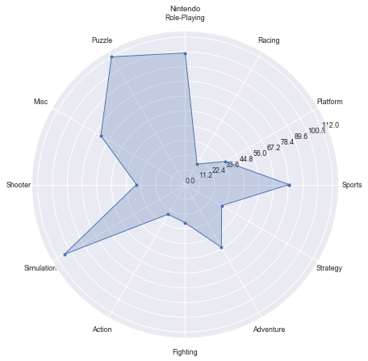

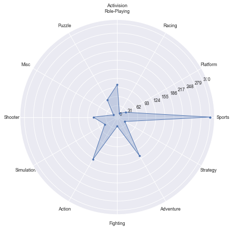

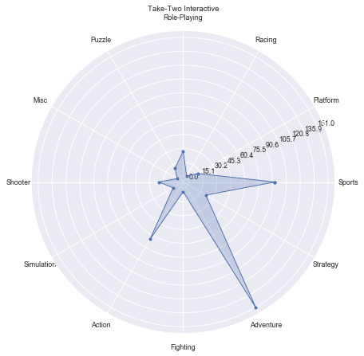

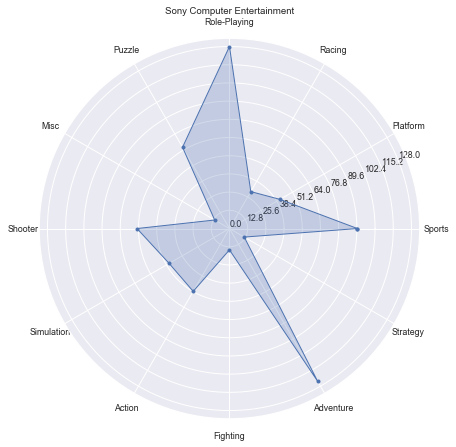

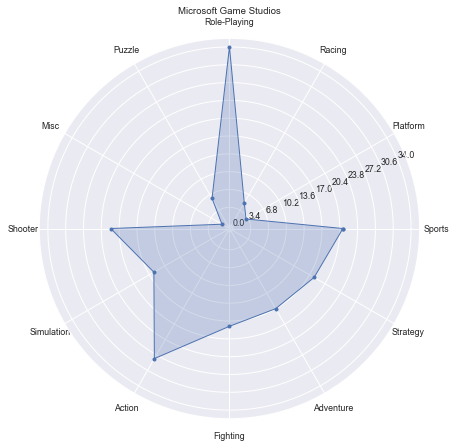

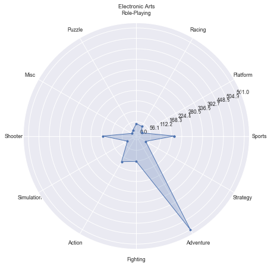

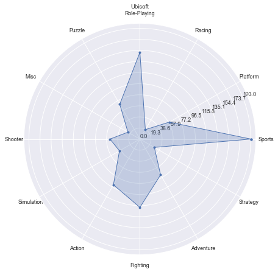

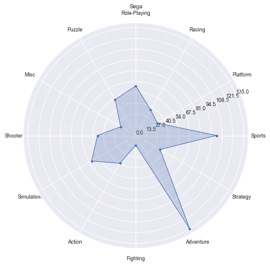

```python
genre = vgsales_df['Genre'].unique()
labels = genre
sns.set(font_scale = 0.8)
for publisher in great_pub:
    markers = np.linspace(0,max(pub_genre[publisher]),num = 11)
    str_markers = [str(x) for x in markers]
    def radar_chart(title, stats, att_labels = labels, plot_markers = markers, plot_str_markers = str_markers):

        labels = np.array(att_labels)

        angles = np.linspace(0, 2*np.pi, len(labels), endpoint=False)
        stats = np.concatenate((stats,[stats[0]]))
        angles = np.concatenate((angles,[angles[0]]))

        fig= plt.figure(figsize=(7,7))
        ax = fig.add_subplot(111, polar=True)
        ax.plot(angles, stats, '.-', linewidth=1)
        ax.fill(angles, stats, alpha=0.25)
        ax.set_thetagrids(angles * 180/np.pi, labels)
        plt.yticks(markers)
        ax.set_title(title)
        ax.grid(True)

        return plt.show()

    radar_chart(publisher, pub_genre[publisher])
```

## Prediction of game sales model

The last part of our tutorial is to build a model to predict video games sales. We think GDP data can explain part of question, so we first merge these two data set. And then, we build a KNeighborsRegressor model with k being 20, but the result show a large bias. Thus we decide to find the k that can optimize our model. We use top 2000 games to do this regression.

```python
vg_df = vgsales_df.merge(gdp_df, on=["Year"])
vg_df.head()
```

|  | Rank | Name | Platform | Year | Genre | Publisher | NA_Sales | EU_Sales | JP_Sales | Other_Sales | Global_Sales | Euro area | North America | Japan | World |
| --- | --- | --- | --- | --- | --- | --- | --- | --- | --- | --- | --- | --- | --- | --- | --- |
| 0 | 1 | Wii Sports | Wii | 2006 | Sports | Nintendo | 41.49 | 29.02 | 3.77 | 8.46 | 82.74 | 33802.30781 | 45724.25136 | 35433.98896 | 7801.883183 |
| 1 | 7 | New Super Mario Bros. | DS | 2006 | Platform | Nintendo | 11.38 | 9.23 | 6.50 | 2.90 | 30.01 | 33802.30781 | 45724.25136 | 35433.98896 | 7801.883183 |
| 2 | 8 | Wii Play | Wii | 2006 | Misc | Nintendo | 14.03 | 9.20 | 2.93 | 2.85 | 29.02 | 33802.30781 | 45724.25136 | 35433.98896 | 7801.883183 |
| 3 | 21 | Pokemon Diamond/Pokemon Pearl | DS | 2006 | Role-Playing | Nintendo | 6.42 | 4.52 | 6.04 | 1.37 | 18.36 | 33802.30781 | 45724.25136 | 35433.98896 | 7801.883183 |
| 4 | 101 | The Legend of Zelda: Twilight Princess | Wii | 2006 | Action | Nintendo | 3.83 | 2.19 | 0.60 | 0.70 | 7.31 | 33802.30781 | 45724.25136 | 35433.98896 | 7801.883183 |

```python
# TYPE YOUR CODE HERE
from sklearn.preprocessing import StandardScaler
from sklearn.neighbors import KNeighborsClassifier
from sklearn.neighbors import KNeighborsRegressor
from sklearn.feature_extraction import DictVectorizer
from sklearn.preprocessing import StandardScaler

vg_df = vg_df.dropna(subset = ['Publisher'])

features = ["Platform", "Year", "Genre","World"]

# Define the training data.
# Represent the features as a list of dicts.
X_train_dict = vg_df[features].to_dict(orient="records")
y_train = vg_df["Global_Sales"]

# Dummy encoding
vec = DictVectorizer(sparse=False)
vec.fit(X_train_dict)
X_train = vec.transform(X_train_dict)

# Standardization
scaler = StandardScaler()
scaler.fit(X_train)
X_train_sc = scaler.transform(X_train)


# K-Nearest Neighbors Model
model = KNeighborsRegressor(n_neighbors=20)
model.fit(X_train_sc, y_train)
```

```
KNeighborsRegressor(algorithm='auto', leaf_size=30, metric='minkowski',
                    metric_params=None, n_jobs=None, n_neighbors=20, p=2,
                    weights='uniform')
```

```python
vg_df = vgsales_df.merge(gdp_df, on=["Year"])
vg_df_2000 = vg_df[vg_df['Rank'] <= 2000]
vg_df_2000.head()
```

|  | Rank | Name | Platform | Year | Genre | Publisher | NA_Sales | EU_Sales | JP_Sales | Other_Sales | Global_Sales | Euro area | North America | Japan | World |
| --- | --- | --- | --- | --- | --- | --- | --- | --- | --- | --- | --- | --- | --- | --- | --- |
| 0 | 1 | Wii Sports | Wii | 2006 | Sports | Nintendo | 41.49 | 29.02 | 3.77 | 8.46 | 82.74 | 33802.30781 | 45724.25136 | 35433.98896 | 7801.883183 |
| 1 | 7 | New Super Mario Bros. | DS | 2006 | Platform | Nintendo | 11.38 | 9.23 | 6.50 | 2.90 | 30.01 | 33802.30781 | 45724.25136 | 35433.98896 | 7801.883183 |
| 2 | 8 | Wii Play | Wii | 2006 | Misc | Nintendo | 14.03 | 9.20 | 2.93 | 2.85 | 29.02 | 33802.30781 | 45724.25136 | 35433.98896 | 7801.883183 |
| 3 | 21 | Pokemon Diamond/Pokemon Pearl | DS | 2006 | Role-Playing | Nintendo | 6.42 | 4.52 | 6.04 | 1.37 | 18.36 | 33802.30781 | 45724.25136 | 35433.98896 | 7801.883183 |
| 4 | 101 | The Legend of Zelda: Twilight Princess | Wii | 2006 | Action | Nintendo | 3.83 | 2.19 | 0.60 | 0.70 | 7.31 | 33802.30781 | 45724.25136 | 35433.98896 | 7801.883183 |

```python
# use the first 2000 data to do the regression

from sklearn.preprocessing import StandardScaler
from sklearn.neighbors import KNeighborsClassifier
from sklearn.neighbors import KNeighborsRegressor
from sklearn.feature_extraction import DictVectorizer
from sklearn.preprocessing import StandardScaler

vg_df_2000 = vg_df_2000.dropna(subset = ['Publisher'])

features = ["Platform", "Year", "Genre","World"]

# Define the training data.
# Represent the features as a list of dicts.
X_train_dict = vg_df_2000[features].to_dict(orient="records")
y_train = vg_df_2000["Global_Sales"]

# Dummy encoding
vec = DictVectorizer(sparse=False)
vec.fit(X_train_dict)
X_train = vec.transform(X_train_dict)

# Standardization
scaler = StandardScaler()
scaler.fit(X_train)
X_train_sc = scaler.transform(X_train)


# K-Nearest Neighbors Model
model = KNeighborsRegressor(n_neighbors=20)
model.fit(X_train_sc, y_train)
```

```
KNeighborsRegressor(algorithm='auto', leaf_size=30, metric='minkowski',
                    metric_params=None, n_jobs=None, n_neighbors=20, p=2,
                    weights='uniform')
```

```python
# use the first 2000 data to do the regression
from sklearn.preprocessing import StandardScaler
from sklearn.neighbors import KNeighborsClassifier
from sklearn.neighbors import KNeighborsRegressor
from sklearn.feature_extraction import DictVectorizer
from sklearn.preprocessing import StandardScaler

vg_df_2000 = vg_df_2000.dropna(subset = ['Publisher'])

features = ["Platform", "Year", "Genre","World", "Publisher"]

# Define the training data.
# Represent the features as a list of dicts.
X_train_dict = vg_df_2000[features].to_dict(orient="records")
X_new_dict = [{
    "Platform":'Wii',
    "Year": 2006,
    "Genre": 'Sports',
    "World" : 7801.883183,
    "Publisher": "Nintendo"
    }]
y_train = vg_df_2000["Global_Sales"]

# Dummy encoding
vec = DictVectorizer(sparse=False)
vec.fit(X_train_dict)
X_train = vec.transform(X_train_dict)
X_new = vec.transform(X_new_dict)

# Standardization
scaler = StandardScaler()
scaler.fit(X_train)
X_train_sc = scaler.transform(X_train)
X_new_sc = scaler.transform(X_new)


# K-Nearest Neighbors Model
model = KNeighborsRegressor(n_neighbors=5)
model.fit(X_train_sc, y_train)
model.predict(X_new_sc)
```

```
array([32.616])
```

```
19    14.020687
13    14.036254
18    14.118042
12    14.121128
17    14.127614
15    14.139815
16    14.164836
10    14.169477
14    14.304068
11    14.358729
8     14.659930
9     14.687507
7     15.307005
6     15.761578
5     16.651463
4     17.926252
3     20.027871
2     23.443984
1     37.208368
dtype: float64
```

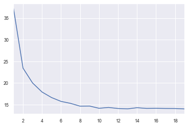

```python
from sklearn.pipeline import Pipeline
from sklearn.model_selection import cross_val_score

vec = DictVectorizer(sparse=False)
scaler = StandardScaler()


# calculates estimate of test error based on 10-fold cross validation
def get_cv_error(k):
    model = KNeighborsRegressor(n_neighbors=k)
    pipeline = Pipeline([("vectorizer", vec), ("scaler", scaler), ("fit", model)])
    mse = np.mean(-cross_val_score(
        pipeline, X_train_dict, y_train,
        cv=10, scoring="neg_mean_squared_error"
    ))
    return mse

ks = pd.Series(range(1, 20))
ks.index = range(1, 20)
test_errs = ks.apply(get_cv_error)

test_errs.plot.line()
test_errs.sort_values()
```

From the above graph, we can see that k greater or equal than 8 can optimize our model. However, this optimization is limited. The test error is still huge compare to the real sales data. We believe to make the prediction better, we need more data such as game investment and advertising fee.

## Insight & Policy Dicision

In this tutorial, we tested several hypothesis and they fit in with our common sense.